# Texas School District Scores

# Executive Summary

This report identifies Texas school districts with the strongest combination of scale, federal funding support, and student need, with the goal of improving territory prioritization and call preparation.

Key takeaways:

- High-opportunity districts are concentrated in a limited number of geographic clusters rather than evenly distributed statewide.
- The strongest targets combine large enrollment with above-average Title I funding per student.
- District-level context varies meaningfully, making tailored outreach more effective than one-size-fits-all messaging.

The sections below move from a statewide scan (Top 25 districts and map) to district-specific deep dives designed for use immediately before outreach or meetings.

# Top Opportunities in Texas

## Top 25 School Districts

Top 25 Texas School District Leads

Ranked by overall lead score with context for outreach conversations

|  | District | Score | Enrollment | Schools | Title I $ / Student | Econ Disadv % | Child Poverty % | Growth | Why this district |
| --- | --- | --- | --- | --- | --- | --- | --- | --- | --- |
| 1 | DONNA ISD | 97 | 12,937 | 19 | $1,487 | 92% | 51% | ↗ Moderate growth | High Title I funding and high student need |
| 2 | SAN ANTONIO ISD | 97 | 44,047 | 85 | $894 | 87% | 41% | — Stable | Large district with meaningful contract scale |
| 3 | LA JOYA ISD | 96 | 22,942 | 36 | $1,002 | 92% | 42% | — Stable | High Title I funding and high student need |
| 4 | LAREDO ISD | 96 | 20,271 | 30 | $789 | 97% | 44% | ↓ Declining | High community need aligned with federal funding |
| 5 | ALDINE ISD | 96 | 56,419 | 75 | $829 | 87% | 36% | ↗ Moderate growth | Large district with meaningful contract scale |
| 6 | BROWNSVILLE ISD | 96 | 36,140 | 53 | $854 | 89% | 36% | — Stable | Large district with meaningful contract scale |
| 7 | ALIEF ISD | 95 | 38,610 | 47 | $945 | 86% | 35% | — Stable | Large district with meaningful contract scale |
| 8 | PHARR-SAN JUAN-ALAMO ISD | 95 | 29,613 | 45 | $677 | 94% | 37% | ↗ Moderate growth | Balanced mix of scale, funding, and need |
| 9 | EDGEWOOD ISD | 95 | 7,849 | 22 | $1,162 | 94% | 49% | — Stable | High Title I funding and high student need |
| 10 | EDINBURG CISD | 95 | 33,343 | 47 | $850 | 81% | 39% | ↗ Moderate growth | Balanced mix of scale, funding, and need |
| 11 | HOUSTON ISD | 93 | 176,727 | 274 | $961 | 78% | 30% | — Stable | High Title I funding and high student need |
| 12 | DALLAS ISD | 93 | 139,802 | 243 | $693 | 89% | 27% | — Stable | Large district with meaningful contract scale |
| 13 | EDCOUCH-ELSA ISD | 93 | 4,349 | 10 | $1,244 | 92% | 42% | ↓ Declining | High Title I funding and high student need |
| 14 | ROMA ISD | 92 | 6,019 | 10 | $742 | 90% | 46% | ↓ Declining | High community need aligned with federal funding |
| 15 | MERCEDES ISD | 92 | 4,207 | 10 | $962 | 90% | 48% | ↗ Moderate growth | High Title I funding and high student need |
| 16 | SAN BENITO CISD | 92 | 9,073 | 23 | $722 | 85% | 40% | — Stable | Balanced mix of scale, funding, and need |
| 17 | WACO ISD | 92 | 13,376 | 22 | $645 | 88% | 34% | — Stable | Balanced mix of scale, funding, and need |
| 18 | YSLETA ISD | 92 | 34,062 | 50 | $649 | 79% | 33% | — Stable | Balanced mix of scale, funding, and need |
| 19 | WESLACO ISD | 91 | 16,300 | 21 | $696 | 81% | 31% | ↗ Moderate growth | Balanced mix of scale, funding, and need |
| 20 | ZAPATA COUNTY ISD | 91 | 3,290 | 6 | $967 | 89% | 51% | — Stable | High Title I funding and high student need |
| 21 | PASADENA ISD | 91 | 46,491 | 67 | $632 | 82% | 28% | — Stable | Large district with meaningful contract scale |
| 22 | PORT ARTHUR ISD | 91 | 8,041 | 15 | $613 | 87% | 40% | — Stable | Balanced mix of scale, funding, and need |
| 23 | SOUTH SAN ANTONIO ISD | 91 | 7,468 | 14 | $751 | 92% | 30% | — Stable | Balanced mix of scale, funding, and need |
| 24 | ALICE ISD | 91 | 4,297 | 6 | $686 | 89% | 48% | ↓ Declining | High community need aligned with federal funding |
| 25 | MISSION CISD | 90 | 13,765 | 23 | $673 | 86% | 28% | — Stable | Balanced mix of scale, funding, and need |

## Geographic Clusters of Opportunity

In this section we visualize our school districts against the backdrop of the map of Texas. We will be able to see geographic clusters of our top markets. We introduce a Tier for our Lead Score here. This is based on simple cutoffs: A is the Top 15th Percentile, B = 50th to 85th Percentile, and C is the bottom 50th Percentile.

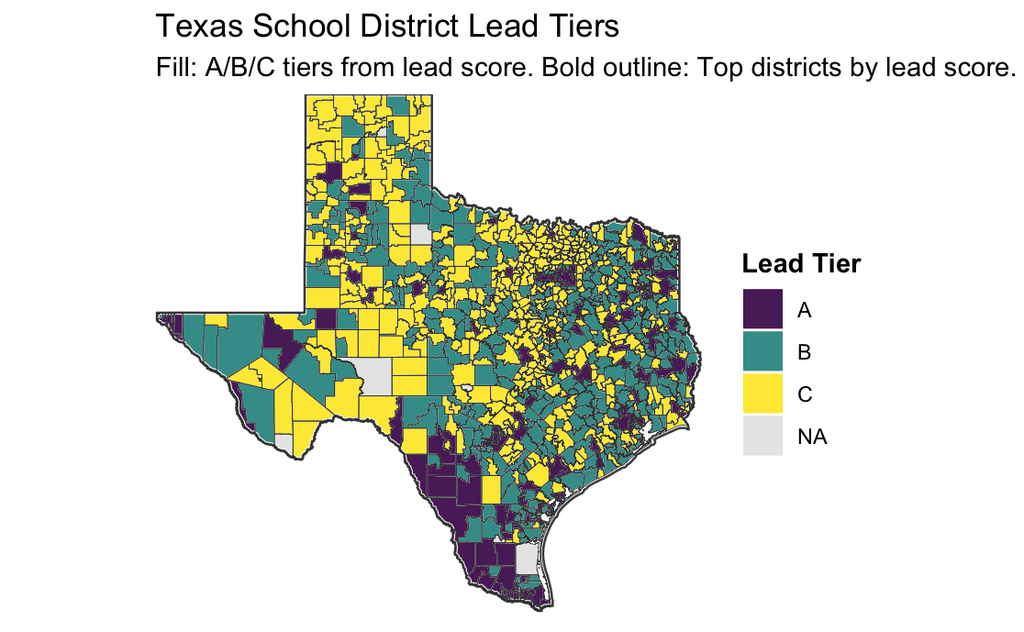

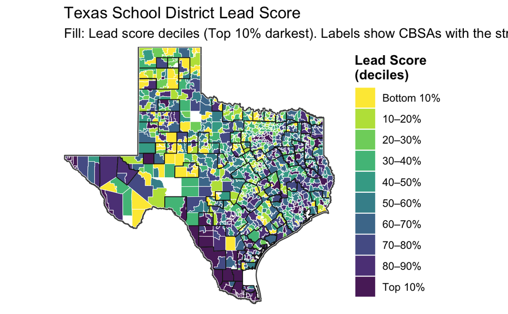

# District Deep Dive

In this section we deep dive into specific districts to see how they compare to Texas at large.

| District | NCES District ID | Lead Score |
| --- | --- | --- |
| DONNA ISD | 4817390 | 96.59187493960253 |
| SAN ANTONIO ISD | 4838730 | 96.5500967483128 |
| LA JOYA ISD | 4826130 | 96.43465050374296 |
| LAREDO ISD | 4826790 | 96.05264636412873 |
| ALDINE ISD | 4807710 | 95.87045389678832 |
| BROWNSVILLE ISD | 4811680 | 95.8623634455434 |
| ALIEF ISD | 4807830 | 95.28555921873209 |
| PHARR-SAN JUAN-ALAMO ISD | 4834860 | 94.81514442579146 |
| EDGEWOOD ISD | 4818150 | 94.69336066107975 |
| EDINBURG CISD | 4818180 | 94.62629980964967 |

[output cut: 1000 more lines]

## Snapshot

Quick Snapshot

| Group | Enrollment | Schools | Title I $ / Student | Econ Disadv % |
| --- | --- | --- | --- | --- |
| Focus District | 42,608 | 55 | $29 | 17% |
| TX Average | 5,050 | 8 | $361 | 59% |

## Score Drivers

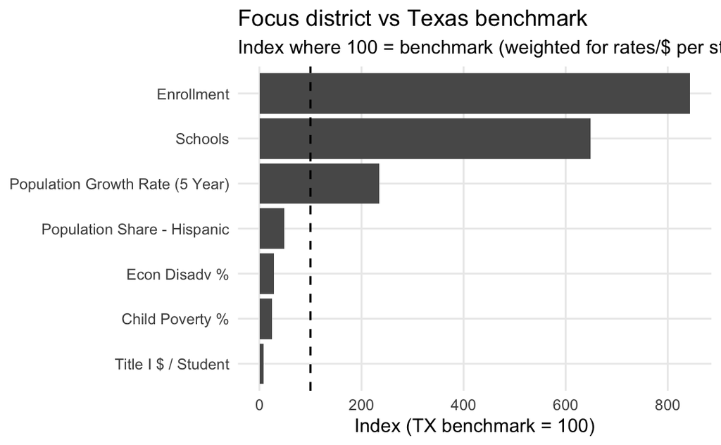

## Additional Context

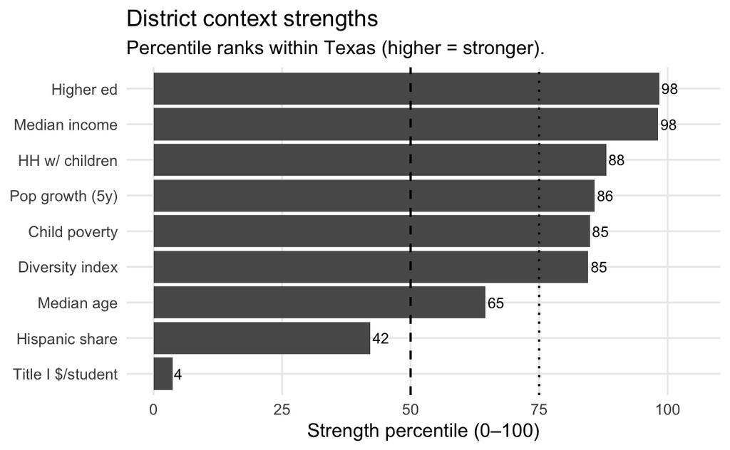